```python
import numpy as np
import pandas as pd
import seaborn as sns
import matplotlib.pyplot as plt
import sklearn
import statsmodels.formula.api as sm
import statsmodels.api as sm
from sklearn import preprocessing, svm
from sklearn.model_selection import train_test_split
from sklearn.linear_model import LinearRegression
from sklearn.discriminant_analysis import LinearDiscriminantAnalysis
from sklearn.tree import DecisionTreeClassifier
from sklearn import tree
from sklearn import datasets
from sklearn.decomposition import PCA
from sklearn.model_selection import train_test_split
from sklearn.model_selection import cross_val_score
from sklearn.metrics import confusion_matrix

data = pd.read_csv('https://raw.githubusercontent.com/jennybc/gapminder/main/data-raw/08_gap-every-five-years.tsv', sep='\t')
data.head()
```

|  | country | continent | year | lifeExp | pop | gdpPercap |
| --- | --- | --- | --- | --- | --- | --- |
| 0 | Afghanistan | Asia | 1952 | 28.801 | 8425333 | 779.445314 |
| 1 | Afghanistan | Asia | 1957 | 30.332 | 9240934 | 820.853030 |
| 2 | Afghanistan | Asia | 1962 | 31.997 | 10267083 | 853.100710 |
| 3 | Afghanistan | Asia | 1967 | 34.020 | 11537966 | 836.197138 |
| 4 | Afghanistan | Asia | 1972 | 36.088 | 13079460 | 739.981106 |

# Part 1

## Exercise 1:

Make a scatter plot of life expectancy across time.

[output not shown]

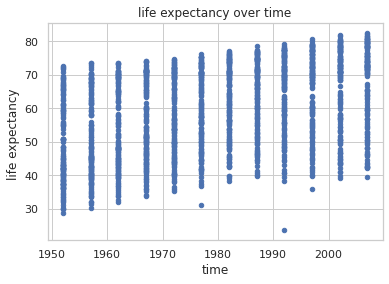

```python
data.plot.scatter(x = 'year', y = 'lifeExp', title = 'life expectancy over time', xlabel='time', ylabel='life expectancy ')
```

### Question 1:

Is there a general trend (e.g., increasing or decreasing) for life expectancy across time? Is this trend linear?

In general we can see there is an increasing trend of longer lives. Which makes sense given as time passes so does technology and medical knowledge. it seems there is a linear relationship since it consitently increases. The min max increases every year but it maintains a range of 40+ years.(excluding the outliers)

### Question 2:

How would you describe the distribution of life expectancy across countries for individual years? Is it skewed, or not? Unimodal or not? Symmetric around it’s center?

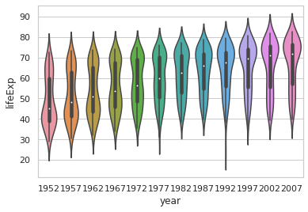

```python
sns.set(style = 'whitegrid')
sns.violinplot(x ="year",
             y ="lifeExp",
             style ="event",
             data = data)
```

From the plot above, we can see that the distribution varies greatly by year. Suppose we look at 1952 we can see that it is bottom heavy, but it appears to have two modes but the upper one is much more relevant, so it is unimodal. The mode is below the median so it is positively skewed. But as time progresses we see the concentation shifts from the bottom to the top making it bimodal from 1957 to 1977, and unimodal for the rest. As for skew from the given information we can see over time it becomes negatively skewed. In 2007 the mode is greater than the median. Its never really symetric except in 1977.

In the future 1992 may become a issue due to the outlier expecially sice regression is sensitive against outliers.

### Question 3:

Suppose I fit a linear regression model of life expectancy vs. year (treating it as a continuous variable), and test for a relationship between year and life expectancy, will you reject the null hypothesis of no relationship? (do this without fitting the model yet. I am testing your intuition.)

Assuming the null hypothesis is time has no impact in life expectancy, we can see that there is strong relationship between years and lifeExp. If this is all of the data and you cannot do proper testing it is reasonable to reject the null hypothesis.

### Question 4:

What would a violin plot of residuals from the linear model in Question 3 vs. year look like? (Again, don’t do the analysis yet, answer this intuitively)

I think it would still be linear but each one would look more symetrical that the violin plot seen above.

### Question 5:

According to the assumptions of the linear regression model, what should that violin plot look like? That is, consider the assumptions the linear regression model you used assumes (e.g., about noise, about input distributions, etc); do you think everything is okay?

The first assumption is linearity or the relationship between years and lifeExp is linear which we confiremed. The second assumption is Homoscedasticity which is variance of residuals is constant. The graph should havemultiple plots centered around some constant hopefully zero. with a normal curve

## Exercise 2:

Fit a linear regression model using, e.g., the LinearRegression function from Scikit-Learn or the closed-form solution, for life expectancy vs. year (as a continuous variable). There is no need to plot anything here, but please print the fitted model out in a readable format.

```python
data_matrix = np.array(data.loc[:, ['year','lifeExp']])
X = data_matrix[:,0]
Y = data_matrix[:,1]
model = LinearRegression(fit_intercept=True)

model.fit(X[:,np.newaxis], Y)
m = model.coef_[0]
b = model.intercept_
print ("Linear Regression: y = {0}x + {1}".format(m, b))

# https://stackoverflow.com/questions/27928275/find-p-value-significance-in-scikit-learn-linearregression
X2 = sm.add_constant(X)
est = sm.OLS(Y, X2)
est2 = est.fit()
print(est2.summary())
```

```
Linear Regression: y = 0.3259038276371518x + -585.6521874415448
                            OLS Regression Results
==============================================================================
Dep. Variable:                      y   R-squared:                       0.190
Model:                            OLS   Adj. R-squared:                  0.189
Method:                 Least Squares   F-statistic:                     398.6
Date:                Fri, 02 Dec 2022   Prob (F-statistic):           7.55e-80
Time:                        00:49:26   Log-Likelihood:                -6597.9
No. Observations:                1704   AIC:                         1.320e+04
Df Residuals:                    1702   BIC:                         1.321e+04
Df Model:                           1
Covariance Type:            nonrobust
==============================================================================
                 coef    std err          t      P>|t|      [0.025      0.975]
------------------------------------------------------------------------------
const       -585.6522     32.314    -18.124      0.000    -649.031    -522.273
x1             0.3259      0.016     19.965      0.000       0.294       0.358
==============================================================================
Omnibus:                      386.124   Durbin-Watson:                   0.197
Prob(Omnibus):                  0.000   Jarque-Bera (JB):               90.750
Skew:                          -0.268   Prob(JB):                     1.97e-20
Kurtosis:                       2.004   Cond. No.                     2.27e+05
==============================================================================

Notes:
[1] Standard Errors assume that the covariance matrix of the errors is correctly specified.
[2] The condition number is large, 2.27e+05. This might indicate that there are
strong multicollinearity or other numerical problems.
```

### Question 6:

On average, by how much does life expectancy increase every year around the world?

by the coeffiecnet which is .325903

### Question 7:

Do you reject the null hypothesis of no relationship between year and life expectancy? Why?

yes we can reject the null hypthesis since we are able to see that there is a positive relationship and a small p value

## Exercise 3:

Make a violin plot of residuals vs. year for the linear model from Exercise 2.

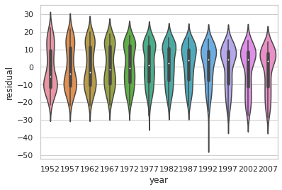

```python
#Residual=actual y value−predicted y
# predicted y = mx + b
# residual = coef*x+intersect

residual = data.copy()
residual['residual'] =  residual['lifeExp'] - (residual['year']*m+b)
sns.set(style = 'whitegrid')
sns.violinplot(x ="year",
             y ="residual",
             style ="event",
             data = residual)
```

### Question 8:

Does the plot of Exercise 3 match your expectations (as you answered Question 4)?

For the most part yes, it is linear but not as symetrical as i would have hoped, but it is to be expected given the orignal datasets skews so heavly on the time bounds and the outliers. but it is mostly symetrical from 1962 to 1977

## Exercise 4:

Make a boxplot (or violin plot) of model residuals vs. continent.

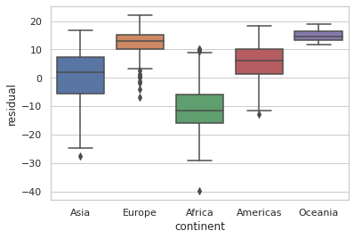

```python
residual = data.copy()
residual['residual'] =  residual['lifeExp'] - (residual['year']*m+b)
residual.sort_values('continent')
sns.set(style = 'whitegrid')
sns.boxplot(x ="continent",
             y ="residual",
             data = residual)
```

### Question 9:

Is there a dependence between model residual and continent? If so, what would that suggest when performing a regression analysis of life expectancy across time?

## Exercise 5:

As in the Moneyball project, make a scatter plot of life expectancy vs. year, grouped by continent, and add a regression line. The result here can be given as either one scatter plot per continent, each with its own regression line, or a single plot with each continent's points plotted in a different color, and one regression line per continent's points. The former is probably easier to code up.

[output not shown]

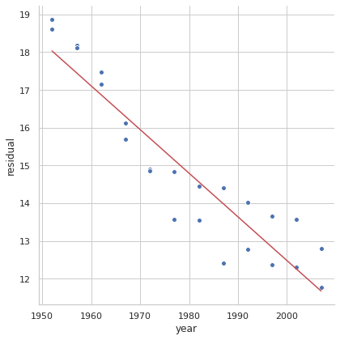

[output not shown]

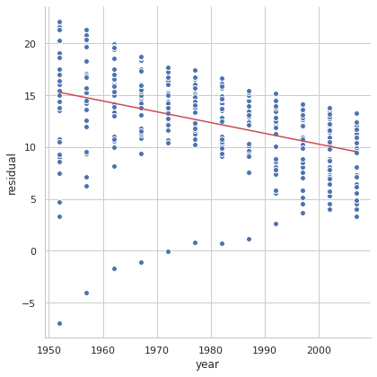

```
cont: Asia
Linear Regression: y = 0.127218576261979x + -251.23870784446137
```

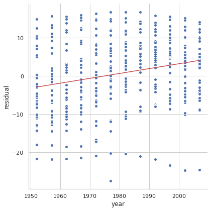

[output not shown]

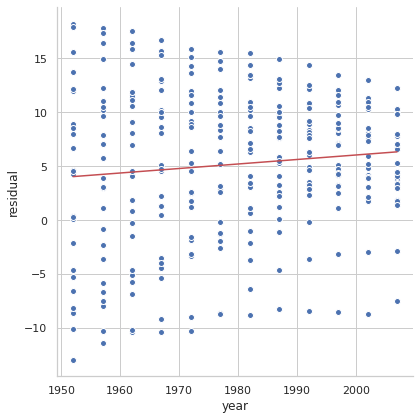

[output not shown]

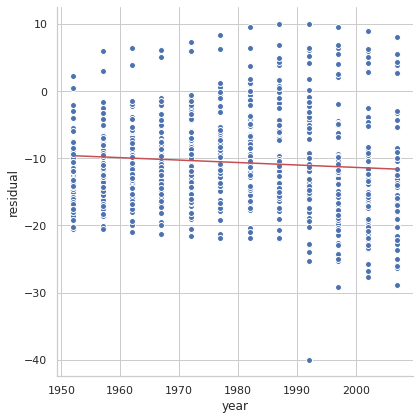

```python
group_names=['Africa','Americas','Asia','Europe','Oceania']
Africa = residual.groupby(['continent']).get_group('Oceania')
Americas = residual.groupby(['continent']).get_group('Europe')
Asia = residual.groupby(['continent']).get_group('Asia')
Europe = residual.groupby(['continent']).get_group('Americas')
Oceania = residual.groupby(['continent']).get_group('Africa')
tables=[Africa,Americas,Asia,Europe,Oceania]
i = 0
for cont in tables:
    data_matrix = np.array(cont.loc[:, ['year','residual']])
    X = data_matrix[:,0]
    Y = data_matrix[:,1]
    model = LinearRegression(fit_intercept=True)

    model.fit(X[:,np.newaxis], Y)
    m = model.coef_[0]
    b = model.intercept_
    print ("cont: {0}".format(group_names[i]))
    print ("Linear Regression: y = {0}x + {1}".format(m, b))
    X_plot = np.linspace(X.min(), X.max(), 100)
    Y_plot = m*X_plot+b
    graph = sns.FacetGrid(cont, height = 6)
    graph = graph.map(plt.scatter, "year", "residual", edgecolor="w")
    plt.plot(X_plot, Y_plot, color='r')
    plt.show()
    i = i + 1
```

### Question 10:

Based on this plot, should your regression model include an interaction term for continent and year? Why?

## Exercise 6:

Fit a linear regression model for life expectancy including a term for an interaction between continent and year. Print out the model in a readable format, e.g., print the coefficients of the model (no need to plot). Hint: adding interaction terms is a form of feature engineering, like we discussed in class (think about, e.g., using (a subset of) polynomial features here).

```python
# Y = c_0 + c_1X_1 + c_2X_2 + c_3+X1_X2
# I expect the effect of changes in continent will effect lifeExp
# to be the same effect with different intensity
# In short, A*B is same as saying A + B + A:B, where A:B indicates "multiplication"
diff_conts = smi.ols(formula="lifeExp ~ continent*year", data=residual).fit()
print (diff_conts.summary())
```

```
                            OLS Regression Results
==============================================================================
Dep. Variable:                lifeExp   R-squared:                       0.693
Model:                            OLS   Adj. R-squared:                  0.691
Method:                 Least Squares   F-statistic:                     424.3
Date:                Fri, 02 Dec 2022   Prob (F-statistic):               0.00
Time:                        00:49:32   Log-Likelihood:                -5771.9
No. Observations:                1704   AIC:                         1.156e+04
Df Residuals:                    1694   BIC:                         1.162e+04
Df Model:                           9
Covariance Type:            nonrobust
==============================================================================================
                                 coef    std err          t      P>|t|      [0.025      0.975]
----------------------------------------------------------------------------------------------
Intercept                   -524.2578     32.963    -15.904      0.000    -588.911    -459.605
continent[T.Americas]       -138.8484     57.851     -2.400      0.016    -252.315     -25.382
continent[T.Asia]           -312.6330     52.904     -5.909      0.000    -416.396    -208.870
continent[T.Europe]          156.8469     54.498      2.878      0.004      49.957     263.737
continent[T.Oceania]         182.3499    171.283      1.065      0.287    -153.599     518.298
year                           0.2895      0.017     17.387      0.000       0.257       0.322
continent[T.Americas]:year     0.0781      0.029      2.673      0.008       0.021       0.135
continent[T.Asia]:year         0.1636      0.027      6.121      0.000       0.111       0.216
continent[T.Europe]:year      -0.0676      0.028     -2.455      0.014      -0.122      -0.014
continent[T.Oceania]:year     -0.0793      0.087     -0.916      0.360      -0.249       0.090
==============================================================================
Omnibus:                       27.121   Durbin-Watson:                   0.242
Prob(Omnibus):                  0.000   Jarque-Bera (JB):               44.106
Skew:                          -0.121   Prob(JB):                     2.65e-10
Kurtosis:                       3.750   Cond. No.                     2.09e+06
==============================================================================

Notes:
[1] Standard Errors assume that the covariance matrix of the errors is correctly specified.
[2] The condition number is large, 2.09e+06. This might indicate that there are
strong multicollinearity or other numerical problems.
```

### Question 11:

Are all parameters in the model significantly (in the p-value sense) different from zero? If not, which are not significantly different from zero? Other libraries (statsmodels or patsy may help you solve this problem)

https://www.statology.org/statsmodels-linear-regression-p-value/

if we look at the P > |t| coumn we can see the p values in the model. Most of them are insignificant or less than .05. But Oceania has a high values. Though unless im misinterpretting somthing i am unsure why Africa is not in the model, the only thing i can think of is that it just does not have its own title so its data is being represented by Intercept and year, but it does not change the answer to this question.

### Question 12:

On average, by how much does life expectancy increase each year for each continent? (Provide code to answer this question by extracting relevant estimates from model fit)

remember for some reason : is like the multiplicaiton.

Africa: 0.289529

```python
print ("Average change per year in")
print (diff_conts.params)
```

```
Average change per year in
Intercept                    -524.257846
continent[T.Americas]        -138.848447
continent[T.Asia]            -312.633049
continent[T.Europe]           156.846852
continent[T.Oceania]          182.349883
year                            0.289529
continent[T.Americas]:year      0.078122
continent[T.Asia]:year          0.163593
continent[T.Europe]:year       -0.067597
continent[T.Oceania]:year      -0.079257
dtype: float64
```

### Exercise 7:

Make a residuals vs. year violin plot for the interaction model. Comment on how well it matches assumptions of the linear regression model.

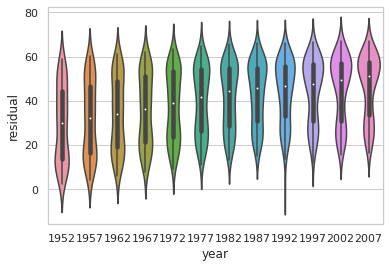

```python
#use the model we made in exercise 6 to make our predictions to find the residual values?
# Y = c_0 + c_1X_1 + c_2X_2 + c_3+X1_X2
# i have no idea how to do this we got like 10 params
residual_Americas = Americas
residual_Americas['residual'] =  residual_Americas['lifeExp'] - (residual_Americas['year']*( 0.078122) + (-138.848447))

residual_Asia = Asia
residual_Asia['residual'] =  residual_Asia['lifeExp'] - (residual_Asia['year']*(0.163593) + (-312.633049))

residual_Europe = Europe
residual_Europe['residual'] =  residual_Europe['lifeExp'] - (residual_Europe['year']*(-0.067597) + (156.846852))

residual_Oceania = Oceania
residual_Oceania['residual'] =  residual_Oceania['lifeExp'] - (residual_Oceania['year']*(-0.079257) + (182.349883))

residual_Africa = Africa
residual_Africa['residual'] =  residual_Africa['lifeExp'] - (residual_Africa['year']*(0.289529) + (-524.257846))

frames = [residual_Americas, residual_Asia, residual_Europe, residual_Oceania, residual_Africa]
result = pd.concat(frames)

sns.set(style = 'whitegrid')
sns.violinplot(x ="year",
             y ="residual",
             style ="event",
             data = result)
```

The Shape is similar to what i expected since there is still a linear realtionship between all of hte violins. Also the right most plot still is clustered at the top. Idealy i should of been centered along 0 with much more symetry but i had no idea how to plot this.

# Part 2

I will be using the iris dataset since I like flowers. It is a multi class classification dataset there are 3 classes, 50 samples per class, and a dimenesionality of 4. What this means is there is 4 columns that are used to make decisions, with the last row being the row's target classification.

### Independent Vars/Predictors

S_len, S_wid, P_len, P_wid

### Dependent Var

Target(0-2)

### goal

given the leaves and sepals we should be able to distinguish the type of flower given without ever seeing it.

```python
# import some data to play with
iris_arr = datasets.load_iris()
iris_df = pd.DataFrame(data= np.c_[iris['data'], iris['target']],
                     columns= iris['feature_names'] + ['target'])
```

# Algorithms

1. Linear Discriminant Analysis() I will be trying to transform the data into one dimension
2. decision tree maintaining the depth is extremely important since too much and it will over fit and too little it wont have enought to make a good decison. a good depth is under 5.

# Data Exploration

```python
(iris_df[iris_df['target'] == 0].corr())
(iris_df[iris_df['target'] == 1].corr())
(iris_df[iris_df['target'] == 2].corr())
```

|  | sepal length (cm) | sepal width (cm) | petal length (cm) | petal width (cm) | target |
| --- | --- | --- | --- | --- | --- |
| sepal length (cm) | 1.000000 | 0.457228 | 0.864225 | 0.281108 | NaN |
| sepal width (cm) | 0.457228 | 1.000000 | 0.401045 | 0.537728 | NaN |
| petal length (cm) | 0.864225 | 0.401045 | 1.000000 | 0.322108 | NaN |
| petal width (cm) | 0.281108 | 0.537728 | 0.322108 | 1.000000 | NaN |
| target | NaN | NaN | NaN | NaN | NaN |

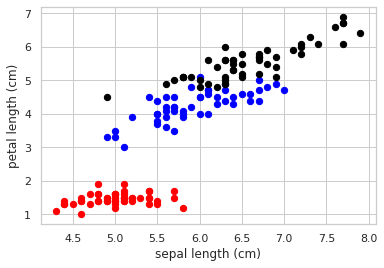

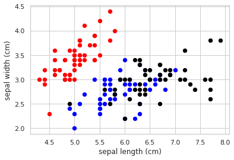

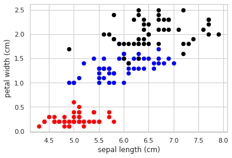

```python
ax = iris_df[iris_df['target'] == 0].plot.scatter(x='sepal length (cm)', y='petal length (cm)', c='red', s=40);
ax = iris_df[iris_df['target'] == 1].plot.scatter(x='sepal length (cm)', y='petal length (cm)', c='blue', s=40,ax=ax);
ax = iris_df[iris_df['target'] == 2].plot.scatter(x='sepal length (cm)', y='petal length (cm)', c='black', s=40,ax=ax);


ax = iris_df[iris_df['target'] == 0].plot.scatter(x='sepal length (cm)', y='sepal width (cm)', c='red', s=40);
ax = iris_df[iris_df['target'] == 1].plot.scatter(x='sepal length (cm)', y='sepal width (cm)', c='blue', s=40,ax=ax);
ax = iris_df[iris_df['target'] == 2].plot.scatter(x='sepal length (cm)', y='sepal width (cm)', c='black', s=40,ax=ax);


ax = iris_df[iris_df['target'] == 0].plot.scatter(x='sepal length (cm)', y='petal width (cm)', c='red', s=40);
ax = iris_df[iris_df['target'] == 1].plot.scatter(x='sepal length (cm)', y='petal width (cm)', c='blue', s=40,ax=ax);
ax = iris_df[iris_df['target'] == 2].plot.scatter(x='sepal length (cm)', y='petal width (cm)', c='black', s=40,ax=ax);
```

# Setting up the models

## testing LDA

```
0.98
```

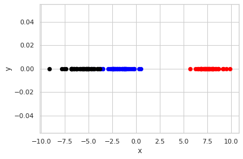

```python
X, y = iris_arr.data, iris_arr.target
LDA = LinearDiscriminantAnalysis(n_components=1)

proj = LDA.fit_transform(X, y)


n = proj.shape[0]
newData = pd.DataFrame(data={
    'class' : iris_df['target'],
    'x' : proj.reshape(n),
    'y' : np.zeros(n)
})
print (LDA.score(X,y))

ax = newData[newData['class'] == 0].plot.scatter(x='x', y='y', c='red', s=40);
ax = newData[newData['class'] == 1].plot.scatter(x='x', y='y', c='blue', s=40,ax=ax);
ax = newData[newData['class'] == 2].plot.scatter(x='x', y='y', c='black', s=40,ax=ax);
```

This is similar to what i expected, classifying 1 and 2 have some overlap/confusion while class 0 was identified pretty easily. This should be reifoced by a confusion matrix.

```python
X_train, X_test, y_train, y_test = train_test_split(X, y, test_size=0.4, random_state=0)
LDA = LDA.fit(X_train, y_train)
print(LDA.score(X_test, y_test))
confusion_matrix(y_test, LDA.predict(X_test))
```

```
0.95
```

```
array([[16,  0,  0],
       [ 0, 22,  1],
       [ 0,  2, 19]])
```

## testing decison tree

```python
# finding a good depth
X, y = iris_arr.data, iris_arr.target
clf1 = DecisionTreeClassifier(max_depth=1)
clf1 = clf1.fit(X, y )
print (clf1.score(X,y))
clf2 = DecisionTreeClassifier(max_depth=2)
clf2 = clf2.fit(X, y )
print (clf2.score(X,y))
clf3 = DecisionTreeClassifier(max_depth=3)
clf3 = clf3.fit(X, y )
print (clf3.score(X,y))
clf4 = DecisionTreeClassifier(max_depth=4)
clf4 = clf4.fit(X, y )
print (clf4.score(X,y))
```

```
0.6666666666666666
0.96
0.9733333333333334
0.9933333333333333
```

It seems at the first level there is a very strong predictor at depth 1 im not completley sure what that feature is but im confident that it is taking out the first class from the set, and the rest of the tree is for classifying 1 and 2.

[output not shown]

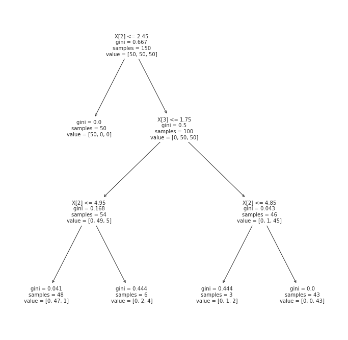

```python
clf3 = clf3.fit(X, y )
print (clf5.score(X,y))

plt.figure(figsize=(12,12))
tree.plot_tree(clf3, fontsize=10)
plt.show()
```

```python
X_train, X_test, y_train, y_test = train_test_split(X, y, test_size=0.4, random_state=0)
clf = clf3.fit(X_train, y_train)
print(clf.score(X_test, y_test))
confusion_matrix(y_test, clf.predict(X_test))
```

[output not shown]

[output not shown]

# Comparing algs

## Decision tree: clf3

## Linear Discriminant Analysis: LDA

```python
scores = cross_val_score(clf3, X, y, cv=10)
print(scores)
print("{0} accuracy with a standard deviation of {1}" .format(scores.mean(), scores.std()))
```

```
[1.         0.93333333 1.         0.93333333 0.93333333 0.93333333
 0.93333333 0.93333333 1.         1.        ]
0.96 accuracy with a standard deviation of 0.03265986323710903
```

```python
scores = cross_val_score(LDA, X, y, cv=10)
print(scores)
print("{0} accuracy with a standard deviation of {1}" .format(scores.mean(), scores.std()))
```

```
[1.         1.         1.         1.         0.93333333 1.
 0.86666667 1.         1.         1.        ]
0.9800000000000001 accuracy with a standard deviation of 0.04268749491621898
```

```python
scores = cross_val_score(clf4, X, y, cv=10)
print(scores)
print("{0} accuracy with a standard deviation of {1}" .format(scores.mean(), scores.std()))
```

```
[1.         0.93333333 1.         0.93333333 0.93333333 0.86666667
 0.93333333 1.         1.         1.        ]
0.96 accuracy with a standard deviation of 0.044221663871405324
```

Two things: first it seems for a problem like this it is better to use LDA over decision trees since it had overall better accuracy but a higher standard deviation. Also i would not add more than three levels to the tree since the accuracy doesnt change, but it risks overfitting anything more than three. Second for a dataset like this i chose to use cross validation over holdout given the size of it. It is only 150 elements large making it quite small. this is where cross validation is best, given a larger dataset it might be better to use holdout. Even so i did do some holdout validation which came to similar results.

## Decision tree

```python
X_train, X_test, y_train, y_test = train_test_split(X, y, test_size=0.7, random_state=0)
clf = clf3.fit(X_train, y_train)
print(clf.score(X_test, y_test))
confusion_matrix(y_test, clf.predict(X_test))
```

[output not shown]

[output not shown]

## LDA

```python
X_train, X_test, y_train, y_test = train_test_split(X, y, test_size=0.7, random_state=0)
LDA = LDA.fit(X_train, y_train)
print(LDA.score(X_test, y_test))
confusion_matrix(y_test, LDA.predict(X_test))
```

```
0.9714285714285714
```

```
array([[33,  0,  0],
       [ 0, 33,  1],
       [ 0,  2, 36]])
```